# Machine Learning Project 1

```python
import pandas as pd
data = pd.read_csv("/Users/joenemeczky/Desktop/Star39552_balanced.csv")
```

```python
data.head()
```

|  | Vmag | Plx | e_Plx | B-V | SpType | Amag | TargetClass |
| --- | --- | --- | --- | --- | --- | --- | --- |
| 0 | 10.00 | 31.66 | 6.19 | 1.213 | K7V | 22.502556 | 1 |
| 1 | 8.26 | 3.21 | 1.00 | 1.130 | K0III | 15.792525 | 0 |
| 2 | 8.27 | 12.75 | 1.06 | 0.596 | F9V | 18.797552 | 1 |
| 3 | 6.54 | 5.23 | 0.76 | 1.189 | K1III | 15.132508 | 0 |
| 4 | 8.52 | 0.96 | 0.72 | 0.173 | B8V | 13.431356 | 1 |

```python
df = data.drop('SpType', axis=1)
df = df.drop('e_Plx', axis=1)
```

```python
df.head()
```

|  | Vmag | Plx | B-V | Amag | TargetClass |
| --- | --- | --- | --- | --- | --- |
| 0 | 10.00 | 31.66 | 1.213 | 22.502556 | 1 |
| 1 | 8.26 | 3.21 | 1.130 | 15.792525 | 0 |
| 2 | 8.27 | 12.75 | 0.596 | 18.797552 | 1 |
| 3 | 6.54 | 5.23 | 1.189 | 15.132508 | 0 |
| 4 | 8.52 | 0.96 | 0.173 | 13.431356 | 1 |

```python
from sklearn import preprocessing
import numpy as np

min_max_scalar = preprocessing.MinMaxScaler()
df_min_max = min_max_scalar.fit_transform(df)
print(df_min_max)
```

```
[[0.78841871 0.0743592  0.42005208 0.74198983 1.        ]
 [0.65924276 0.03880425 0.3984375  0.52412471 0.        ]
 [0.65998515 0.05072672 0.259375   0.62169365 1.        ]
 ...
 [0.72976986 0.03965407 0.16328125 0.56851649 1.        ]
 [0.71492205 0.03745454 0.48619792 0.51955876 0.        ]
 [0.72308834 0.03956659 0.22916667 0.56431405 1.        ]]
```

```python
from sklearn.model_selection import train_test_split

X, y = df_min_max[:, 0:4], df_min_max[:, 4]
```

```python
X_train, X_test, y_train, y_test =\
    train_test_split(X, y,
                     test_size=0.2,
                     random_state=0,
                     stratify=y)
```

```python
print(X_train)
print(y_train)
print(X_train.shape)
print(y_train.shape)

X_train2 = X_train[:,0:2]
print(X_train2)
```

```
[[0.57535264 0.04137871 0.11510417 0.52238856]
 [0.49591685 0.05867503 0.21041667 0.57846989]
 [0.66295471 0.03554245 0.52265625 0.40750514]
 ...
 [0.50556793 0.04182861 0.52239583 0.49652701]
 [0.62806236 0.03867928 0.52161458 0.50825659]
 [0.70824053 0.03926666 0.39010417 0.55324545]]
[1. 1. 0. ... 0. 0. 0.]
(31641, 4)
(31641,)
[[0.57535264 0.04137871]
 [0.49591685 0.05867503]
 [0.66295471 0.03554245]
 ...
 [0.50556793 0.04182861]
 [0.62806236 0.03867928]
 [0.70824053 0.03926666]]
```

```python
print(X_test)
print(y_test)
print(X_test.shape)
print(y_test.shape)
```

```
[[0.52190052 0.03972906 0.496875   0.47868365]
 [0.52561247 0.07357187 0.2375     0.62563387]
 [0.6325167  0.05797518 0.25182292 0.63611515]
 ...
 [0.63548627 0.04099129 0.40703125 0.54441377]
 [0.37861915 0.04279091 0.14817708 0.45004363]
 [0.62657758 0.05655048 0.24166667 0.6290459 ]]
[0. 1. 1. ... 0. 0. 1.]
(7911, 4)
(7911,)
```

```python
import numpy as np
class Perceptron:

    def __init__(self, eta=0.01, n_iter=50, random_state=1):
        self.eta = eta
        self.n_iter = n_iter
        self.random_state = random_state

    def fit(self, X, y):
        rgen = np.random.RandomState(self.random_state)
        self.w_ = rgen.normal(loc=0.0, scale=0.01, size=X.shape[1])
        self.b_ = np.float_(0.)
        self.errors_ = []

        for _ in range(self.n_iter):
            errors = 0
            for xi, target in zip(X, y):
                update = self.eta * (target - self.predict(xi))
                self.w_ += update * xi
                self.b_ += update
                errors += int(update != 0.0)
            self.errors_.append(errors)
        return self

    def net_input(self, X):
        return np.dot(X, self.w_) + self.b_

    def predict(self, X):
        return np.where(self.net_input(X) >= 0.0, 1, 0)
```

```python
from matplotlib.colors import ListedColormap
def plot_decision_regions(X, y, classifier, resolution=0.02):

    markers = ('o', 's', '^', 'v', '<')
    colors = ('red', 'blue', 'lightgreen', 'gray', 'cyan')
    cmap = ListedColormap(colors[:len(np.unique(y))])
    x1_min, x1_max = X[:, 0].min() - 1, X[:, 0].max() + 1
    x2_min, x2_max = X[:, 1].min() - 1, X[:, 1].max() + 1
    xx1, xx2 = np.meshgrid(np.arange(x1_min, x1_max, resolution),
    np.arange(x2_min, x2_max, resolution))
    lab = classifier.predict(np.array([xx1.ravel(), xx2.ravel()]).T)
    lab = lab.reshape(xx1.shape)
    plt.contourf(xx1, xx2, lab, alpha=0.3, cmap=cmap)
    plt.xlim(xx1.min(), xx1.max())
    plt.ylim(xx2.min(), xx2.max())

    for idx, cl in enumerate(np.unique(y)):
        plt.scatter(x=X[y == cl, 0],
                    y=X[y == cl, 1],
                    alpha=0.8,
                    c=colors[idx],
                    marker=markers[idx],
                    label=f'Class {cl}',
                    edgecolor='black')
```

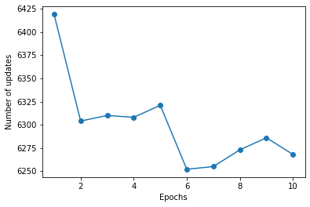

```
Precision: 0.914
```

```python
import matplotlib.pyplot as plt
ppn5 = Perceptron(eta=0.1, n_iter=10)
ppn5.fit(X_train, y_train)
plt.plot(range(1, len(ppn5.errors_) + 1),
         ppn5.errors_, marker='o')
plt.xlabel('Epochs')
plt.ylabel('Number of updates')
plt.show()
predictions5 = ppn5.predict(X_train)
from sklearn.metrics import precision_score
pre_val5 = precision_score(y_true=y_train, y_pred=predictions5)
print(f'Precision: {pre_val5:.3f}')
```

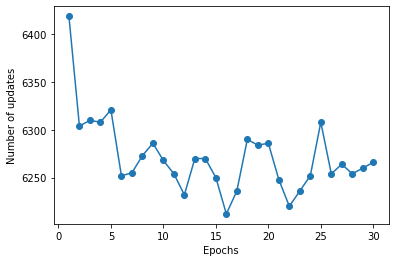

```
Precision: 0.905
```

```python
import matplotlib.pyplot as plt
ppn = Perceptron(eta=0.1, n_iter=30)
ppn.fit(X_train, y_train)
plt.plot(range(1, len(ppn.errors_) + 1),
         ppn.errors_, marker='o')
plt.xlabel('Epochs')
plt.ylabel('Number of updates')
plt.show()
predictions = ppn.predict(X_train)
from sklearn.metrics import precision_score
pre_val = precision_score(y_true=y_train, y_pred=predictions)
print(f'Precision: {pre_val:.3f}')
```

The perceptron after 10 epochs starts to converge but never actually reaches a point of complete convergence. I incremently increased from 10 to 30 epochs and each perceptron was similar where it sort of started to converge but then continued to bounce around within a certain range.

```python
confmat1 = confusion_matrix(y_true = y_train, y_pred = predictions)
print(confmat1)
print(5436+1092)
print(5436+1092+14728+10385)
```

```
[[14728  1092]
 [ 5436 10385]]
6528
31641
```

There are 6528 misclassifications out of the 31641 total cases. This is based on the perceptron with 30 iterations and a learning rate of 0.1

```python
import matplotlib.pyplot as plt
ppn2 = Perceptron(eta=0.1, n_iter=30)
```

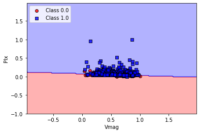

```python
plot_decision_regions(X_train2, y_train, classifier=ppn2)
plt.xlabel('Vmag')
plt.ylabel('Plx')
plt.legend(loc='upper left')
plt.show()
```

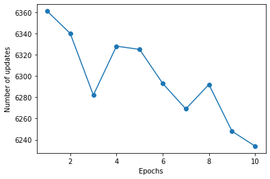

```
Precision: 0.913
```

```python
import matplotlib.pyplot as plt
ppn3 = Perceptron(eta=0.25, n_iter=10)
ppn3.fit(X_train, y_train)
plt.plot(range(1, len(ppn3.errors_) + 1),
         ppn3.errors_, marker='o')
plt.xlabel('Epochs')
plt.ylabel('Number of updates')
plt.show()

predictions3 = ppn3.predict(X_train)
from sklearn.metrics import precision_score
pre_val3 = precision_score(y_true=y_train, y_pred=predictions3)
print(f'Precision: {pre_val3:.3f}')
```

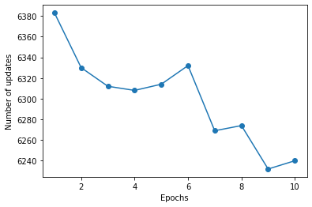

```
Precision: 0.874
```

```python
import matplotlib.pyplot as plt
ppn7 = Perceptron(eta=0.5, n_iter=10)
ppn7.fit(X_train, y_train)
plt.plot(range(1, len(ppn7.errors_) + 1),
         ppn7.errors_, marker='o')
plt.xlabel('Epochs')
plt.ylabel('Number of updates')
plt.show()

predictions7 = ppn7.predict(X_train)
from sklearn.metrics import precision_score
pre_val7 = precision_score(y_true=y_train, y_pred=predictions7)
print(f'Precision: {pre_val7:.3f}')
```

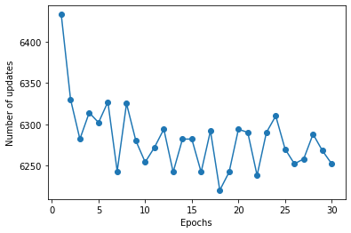

```
Precision: 0.876
```

```python
import matplotlib.pyplot as plt
ppn4 = Perceptron(eta=0.33, n_iter=30)
ppn4.fit(X_train, y_train)
plt.plot(range(1, len(ppn4.errors_) + 1),
         ppn4.errors_, marker='o')
plt.xlabel('Epochs')
plt.ylabel('Number of updates')
plt.show()

predictions4 = ppn4.predict(X_train)
from sklearn.metrics import precision_score
pre_val4 = precision_score(y_true=y_train, y_pred=predictions4)
print(f'Precision: {pre_val4:.3f}')
```

Changing the learning rate didn't change the convergence that much when each one was set to have 10 iterations. When I started to changed both the learning rate and the number of iterations is when I started to see the most change in the convergence. Changing from a learning rate of 0.25 to 0.5 changed the number of incorrect classifications from 7276 to 3958.

```python
from sklearn.metrics import confusion_matrix
confmat1 = confusion_matrix(y_true = y_train, y_pred = predictions)

print(confmat1)
print()

confmat3 = confusion_matrix(y_true = y_train, y_pred = predictions3)
print(confmat3)
print()

confmat4 = confusion_matrix(y_true = y_train, y_pred = predictions4)
print(confmat4)
print(1949+2003)
print()

confmat5 = confusion_matrix(y_true = y_train, y_pred = predictions5)
print(confmat5)
print()

confmat7 = confusion_matrix(y_true = y_train, y_pred = predictions7)
print(confmat7)
print(1993+1965)
print(1993+1965+13827+13856)
print((31641-3958)/31641)
```

```
[[14728  1092]
 [ 5436 10385]]

[[14926   894]
 [ 6382  9439]]

[[13871  1949]
 [ 2003 13818]]
3952

[[14933   887]
 [ 6397  9424]]

[[13827  1993]
 [ 1965 13856]]
3958
31641
0.8749091368793653
```

After testing out all of the confusion matrices for all of the models I found that the perceptron 4 with the inputs (eta=0.33, n_iter=30) and the perceptron 7 with inputs (eta=0.5, n_iter=10) performed the best on the training dataset.

```python
import matplotlib.pyplot as plt
ppn6 = Perceptron(eta=0.5, n_iter=10)
ppn6.fit(X_train2, y_train)
```

```
<__main__.Perceptron at 0x7fa6950a3a30>
```

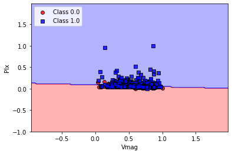

```python
plot_decision_regions(X_train2, y_train, classifier=ppn6)
plt.xlabel('Vmag')
plt.ylabel('Plx')
plt.legend(loc='upper left')
plt.show()
```

```python
predictions7test = ppn7.predict(X_test)
confmat7test = confusion_matrix(y_true = y_test, y_pred = predictions7test)
print(confmat7test)
print(482+509)
print(482+509+3447+3473)
print((7911-991)/7911)
```

```
[[3447  509]
 [ 482 3473]]
991
7911
0.8747313866767792
```

```python
predictions4test = ppn4.predict(X_test)
confmat4test = confusion_matrix(y_true = y_test, y_pred = predictions4test)
print(confmat4test)
print(502+498)
```

```
[[3458  498]
 [ 502 3453]]
1000
```

Since both perceptron 4 and 7 performed similarly on the training dataset I wanted to test both of them out on the test dataset as well. After predicting the values on the test dataset for both I found that perceptron 7 performed better and only had 991 misclassification compared to the 1000 misclassifications for perceptron 4. Overall I thought that the perceptron performed pretty well considering the data was not very linearly separable. It had a successful classification rate of 87.47% on the test dataset. This was almost identical in performance to the training dataset which had a successful classification rate of 87.49%. The only thing that I was confused about was there was not relationship between the precision score that I found and the classification rate. Almost all of the other perceptrons had a higher precision score than the final perceptron that I decided on however it successfully classified the target variable the best.

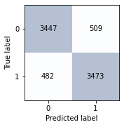

```python
fig, ax = plt.subplots(figsize=(2.5, 2.5))
ax.matshow(confmat7test, cmap=plt.cm.Blues, alpha=0.3)
for i in range(confmat7test.shape[0]):
    for j in range(confmat7test.shape[1]):
        ax.text(x=j, y=i, s=confmat7test[i, j],
                va='center', ha='center')
ax.xaxis.set_ticks_position('bottom')
plt.xlabel('Predicted label')
plt.ylabel('True label')
plt.show()
```